# Plotting Cure Data

Laura White

9/22/2021

## Background

This is a summary of all data that reported on natural recovery of individuals diagnosed with TB disease in the prechemotherapy era. There were 12 published papers with this data. Of these there were 47 cohorts with data.

## Overall plot of all data

Note: one study reports data out to 20 years. Since all other data is within a 10 year framework, we truncate the plot at 10 years.

In the following plots, we connect dots over time for longitudinal follow-up on individuals from the same cohort where loss to follow-up was tracked.

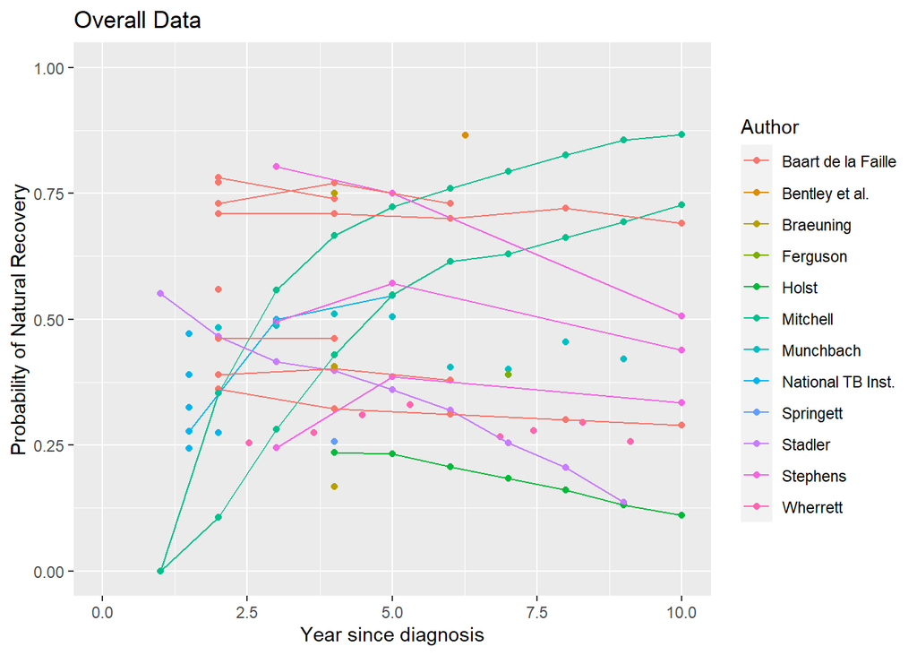

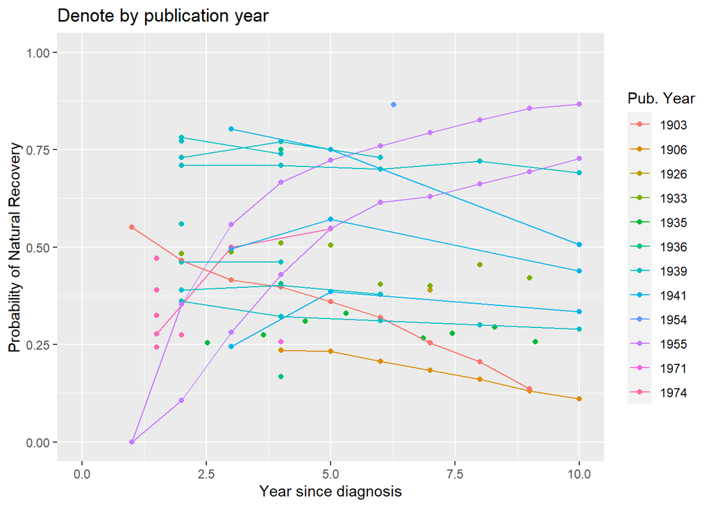

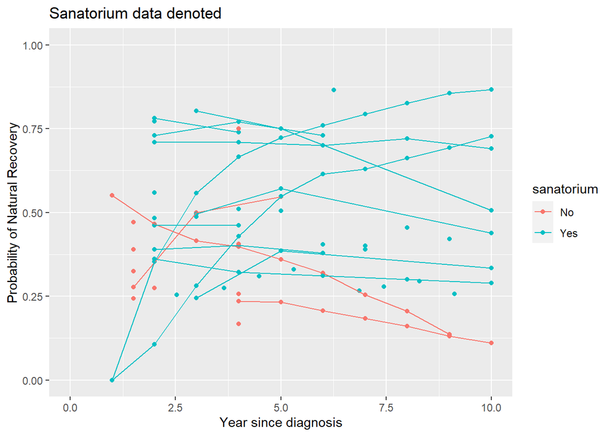

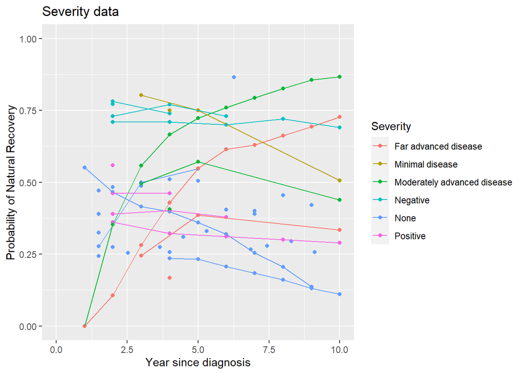

## Plots by severity

Since severity seems to have a substantial impact on the outcomes here. We plot these separately.

First a plot of the data without severity of any kind reported.

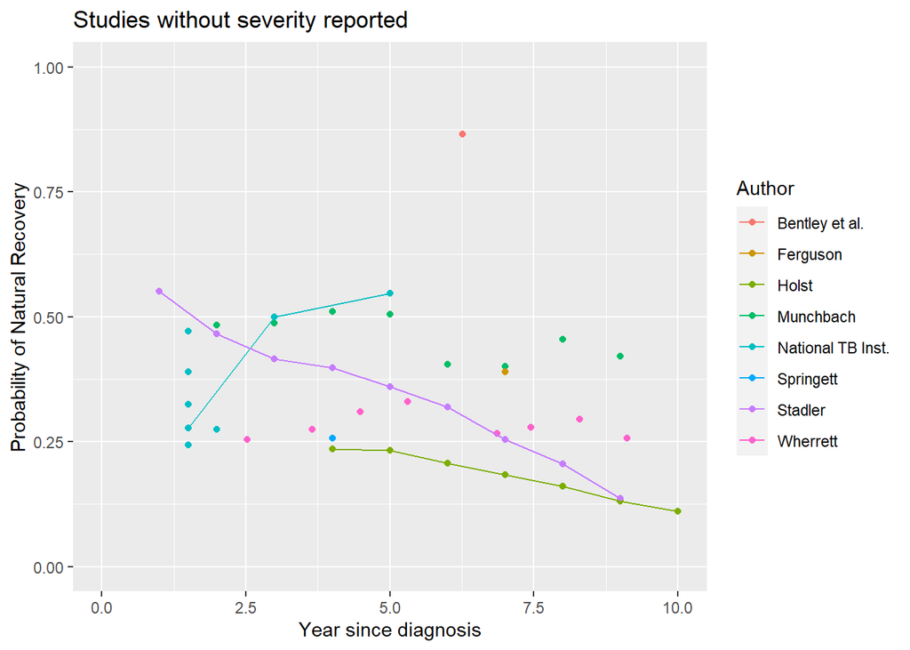

Second a plot of data with severity. One complexity is that severity is reported uniquely for one study of sanitoria patients from the Netherlands. Here individuals were called “positive” if they were positive for TB by microscopy upon entrance to the sanitorium, “negative” individuals were not, but presumably diagnosed clinically.

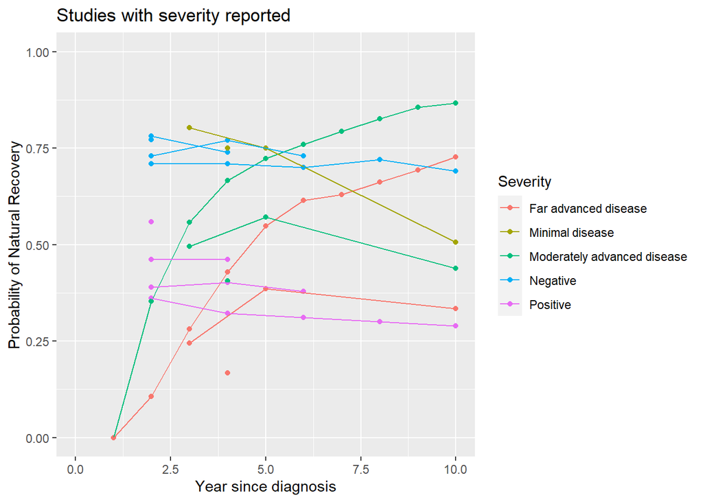

Finally we separate these studies from one another.

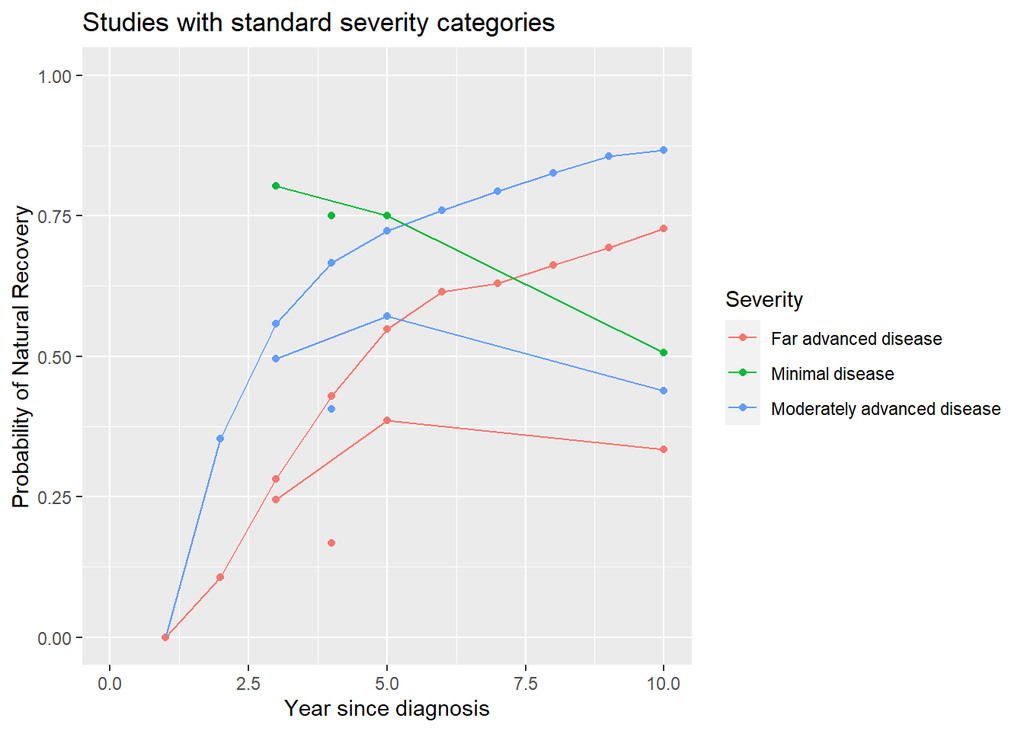

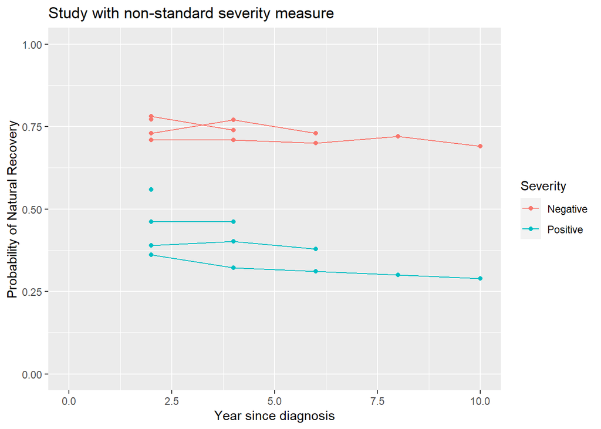